# Flume Run: 11/1/17

Justin Nghiem

11/3/17

*Source files* ⇒ LISST_floc.Rmd ⇒ C:_values.rds

### Flume run on 11/1/17

- sediment: Aquatic Park (collected 10/1/17) and floc (kaolinite, NaCl)
- start collection: 12:05pm
- end collection: 2:05pm
- start flume: did not start flume
- frequency: NA
- flux: 0
- water depth: 44 cm then 45 cm
- slope: 0.00%

#### Notes:

- sediment was left over from previous flume runs (last one on 10/20/17)
- floc mixture included 155.5 g of kaolinite and 31.1 g of NaCl
- some sediment trapped beneath removable test bed
- refill of flume began at 1:35pm to increase depth to 45 cm
- water was relatively clear, little turbidity

The dataset has been processed to remove samples with optical transmission less than 0.1 or greater than 0.995. The plots of the densities use 10-minute time intervals (“groups”).

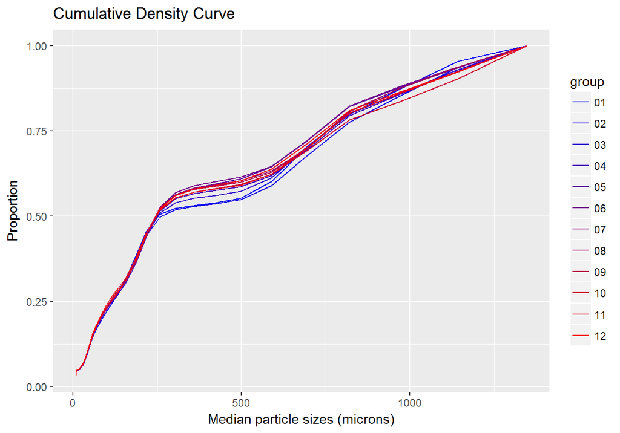

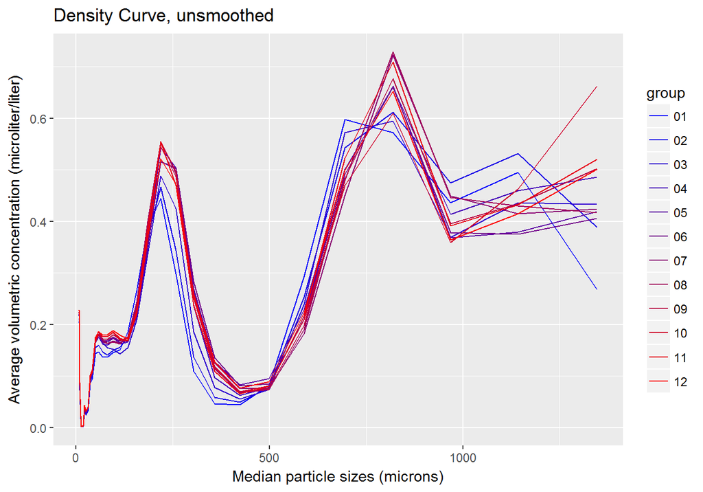

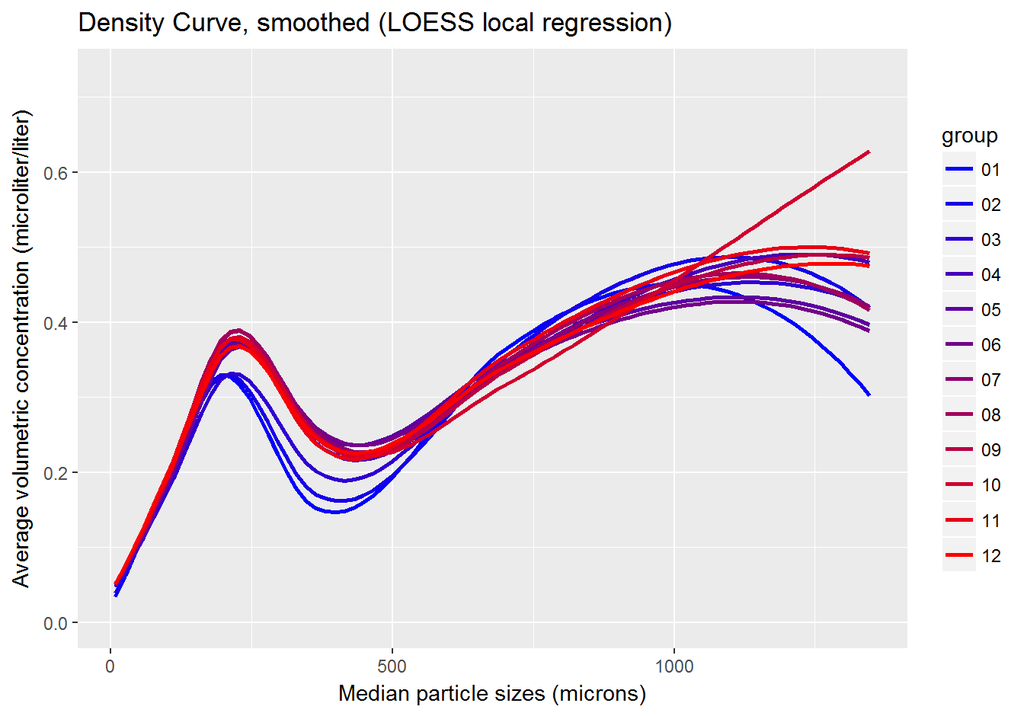

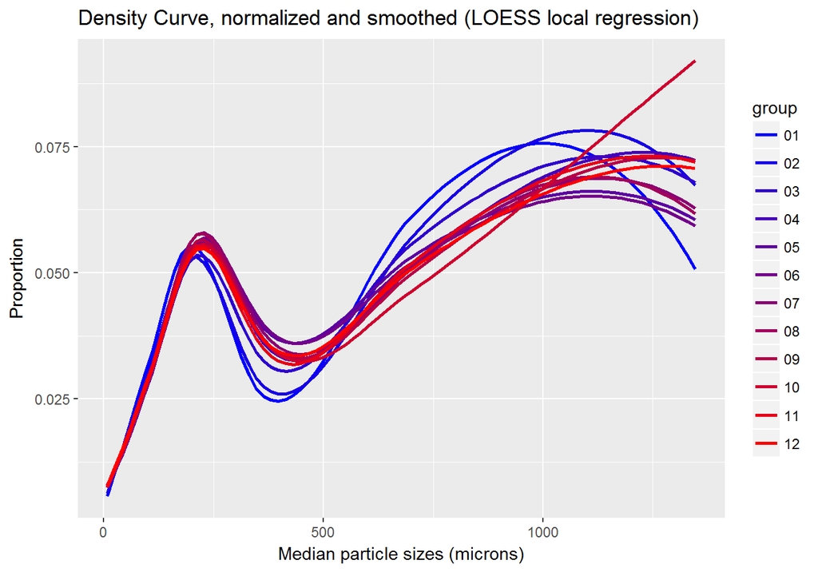

```
## [1] "Number of samples is 7201"
```

| group | avg_size |
| --- | --- |
| 1 | 463.8777 |
| 2 | 468.8070 |
| 3 | 483.1231 |
| 4 | 490.6056 |
| 5 | 492.9825 |
| 6 | 489.7617 |
| 7 | 488.1239 |
| 8 | 496.0492 |
| 9 | 499.0132 |
| 10 | 503.4704 |
| 11 | 510.2476 |
| 12 | 515.2321 |
| 13 | 510.1368 |
| 14 | 502.7217 |
| 15 | 512.7769 |
| 16 | 505.7427 |
| 17 | 495.9864 |
| 18 | 500.6726 |
| 19 | 495.4753 |
| 20 | 501.5585 |
| 21 | 502.0532 |
| 22 | 502.5656 |
| 23 | 489.6289 |
| 24 | 488.2901 |
| 25 | 491.1362 |
| 26 | 492.3808 |
| 27 | 483.0285 |
| 28 | 473.7244 |
| 29 | 474.9884 |
| 30 | 480.2674 |

[output cut: 90 more lines]

`group` denotes the time interval. For example, `group` 1 is the time from the start of the experiment with a length of the time interval. `avg_size` is the mean particle size in microns. In the table above, time intervals are 1-minute. The plot of the table is:

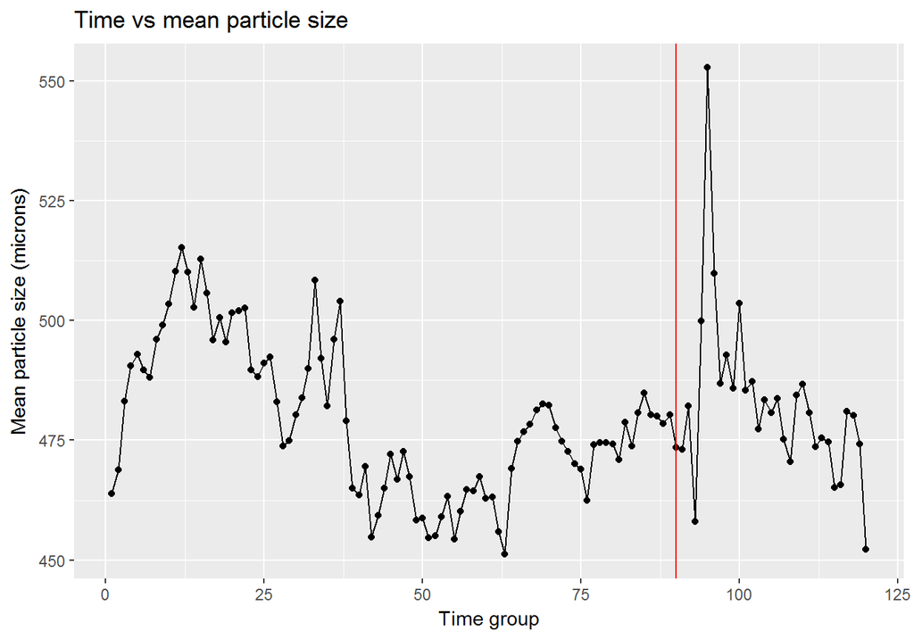

The red line marks the time at which the flume was starting to be filled (approximately 1:35pm or time group 90).

The `mean` of mean particle sizes is 480.202909. The `standard deviation` of mean particle sizes is 16.320592.